# Tokugawa in R

# data

誰でも閲覧でき，登録すれば編集できるデータセット

`https://docs.google.com/spreadsheets/d/1ZzIZ3qGpURU6JYSZfR2cJec9RuhrCFaex131i5kXxPo/edit?usp=sharing`閲覧のみ

## data source

### 寛文印知

wikiに[寛文印知](https://ja.wikipedia.org/wiki/%E5%AF%9B%E6%96%87%E5%8D%B0%E7%9F%A5)というとてもよい表があるので，[wiki table to csv converter](http://wikitable2csv.ggor.de/)をつかってCSVにし，それを簡単に整形してコピペしている

#### category

大名がどれくらいの石高を占めていたか [永高](https://kotobank.jp/word/%E6%B0%B8%E9%AB%98-35946)という単位があるのね

# Libraries

```r
library(sf)
# library(rgdal)
library(tidyverse)
library(ggthemes)
library(extrafont)
library(ggrepel)
library(Cairo)
library(mapview)
library(ggbeeswarm)
library(ggspatial) # for cute north arrow and scale
```

# data

[sfパッケージについて](https://notchained.hatenablog.com/entry/2017/01/06/213333)

```r
tempfile(fileext = ".zip") %>%
  unzip()
# df <- st_read(dsn = "data/jp_toku_dmyo_pgn") obsolete
# https://notchained.hatenablog.com/entry/2017/09/13/102358

# data is from
df <- read_sf(dsn = "data/jp_toku_dmyo_pgn/",
              options = "ENCODING=UTF-8") # できた！
df2 <- read_sf(dsn = "data/jp_toku_dmyo_pts/",
               options = "ENCODING=UTF-8")  # 何に使うのかわからん
df_kuni <- read_sf(dsn = "data/jp_toku_kuni_pgn/",
                   options = "ENCODING=UTF-8")
df_doo <- read_sf(dsn = "data/jp_toku_doo_pgn/",
                  options = "ENCODING=UTF-8")
plot(df_kuni)
View(df_kuni)
plot(df2)

df <- df %>%
  rename(daimyo_id = DMYO_CODE,
         cnt_daimyo_c = CNT_DMYO_C,
         area = ACRES,
         daimyo = DMYO_KJ,
         daimyo_kana = DMYO_KANA,
         daimyo_yomi = DMYO_RMJI,
         is_tozama = DMYO_TYPE,
         kokudaka = DMYO_SALAR,
         domain = SEAT_KJ, #　藩はdomainというらしい
         domain_kana =SEAT_KANA,
         domain_yomi = SEAT_RMJI,
         point_id = POINT_ID,
         heisei_name_yomi = PRESENT_RO,
         heisei_name = PRESENT_KA,
         is_centroid = XY_TYPE,
         x = X_COORD,
         y = Y_COORD
  ) %>%
  mutate(is_tozama = is_tozama - 1,
         kokudaka_per_acre = kokudaka / area)
```

保存しておこう

```r
# export as csv, copy paste to google spreadsheet, add some more info
df %>%
  as_tibble() %>%
  select(-geometry)
write_csv(path = "data/df.csv")
```

# plotいろいろしてみよう

いろいろプロット [参考](https://uribo.hatenablog.com/entry/2018/05/28/075500). [ラベルについて](https://notchained.hatenablog.com/entry/2018/05/28/003910). polygon edge not foundエラーは何度かやるとうまくいくことがある，[geom_sfのissue] (https://github.com/tidyverse/ggplot2/issues/2252).めげずに何度かやってみよう

```r
df_small <- df %>% filter(kokudaka > 11)
df_small %>%
  ggplot() +
  geom_text(
    aes(x = x, y = y,
        label = daimyo,
        # size = area,
        # colour = kokudaka
        # family = if_else(is_tozama == 1, "Meiryo", "Meiryo")
    ),
    family = "HiraKakuPro-W6",
    NULL
  )
```

[figure not shown]

#### coord_sfに関して

package `sf`の[ページ](https://www.r-spatial.org/r/2018/10/25/ggplot2-sf.html)にもある通り，座標系をちゃんとしたもの使わないときれいに`annotation_north_arrow()`や`annotation_scale()`は出ない．特に前者は表示すらされずエラーになる．

`coord_sf(crs = 3995)`などで座標系を上書きできる．`crs`に関しては[座標参照系(Coordinate Reference System:CRS)についてまとめ](https://tm23forest.com/contents/coordinate-reference-system)などを参考に．

PDFにしよう．

### 石高プロット

[figure not shown]

```r
ggsave(
       file = paste0("plot/", Sys.Date(), "_AreaKokudaka.png"),
       family = "Meiryo", # only accepts names(pdfFonts()) fonts.
       width = 1500,
       height = 1500)
```

```
Error: Dimensions exceed 50 inches (height and width are specified in 'in' not pixels). If you're sure you want a plot that big, use `limitsize = FALSE`.
```

日本語フォントがPDFにできねえなー．しかたないのでPNGにしている．ツイートしやすいし．

### mapviewでインタラクティブマップをブラウザでみる

```r
mapview(df, zcol = "kokudaka_per_acre")
```

### 外様大名

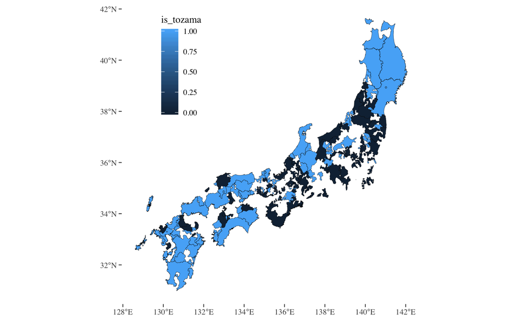

# 最終的に

やりたいこと：

- Google Mapsで見られるようにして公開．せめて1662年を
- Geacronみたいに時系列で動かせるように
- 今のスーパーの勢力圏とかぶるとかいう説をみてみたい
- 山岳との関連をみてみたい
- 表高と実高
- 耕作可能面積を[国土地理院](http://nlftp.mlit.go.jp/ksj/gml/datalist/KsjTmplt-A13.html)の森から逆算して（工業地帯とかも農地と考えたいので）だしてみて，それで豊かさ・貧しさを測る．南部くんが貧しく見えるのはしょうがない気がする
- 新政府軍についたかどうかを見る．
- 超どうでもいいけど徳川（特に家康）の遺伝子がどれくらい広がり，薄まったかを図示できたら面白そう！
- 同様に信長の遺伝子とかも．家光は > 母は浅井長政の娘で織田信長の姪にあたる江。